# Project 1- Applied Data Science

## Genre and year

Next we will look at what the breakdown is per genre. This will be a followup to a previous identifier that the songs will be of more modern form than something that would have been seen in a collection of songs from an older time.

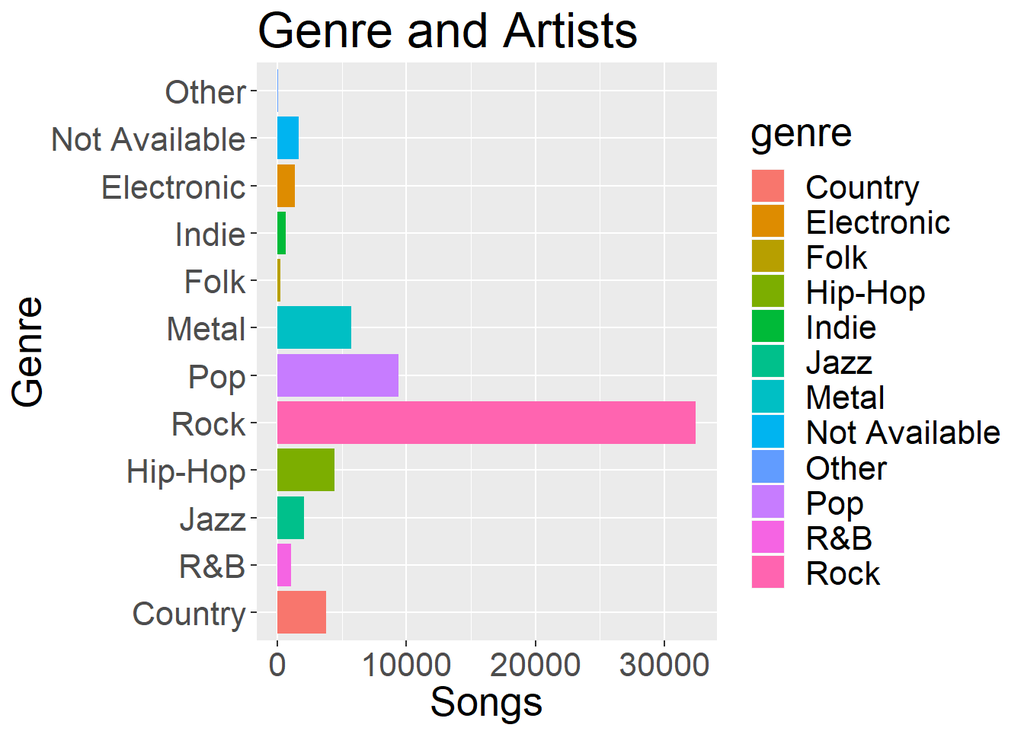

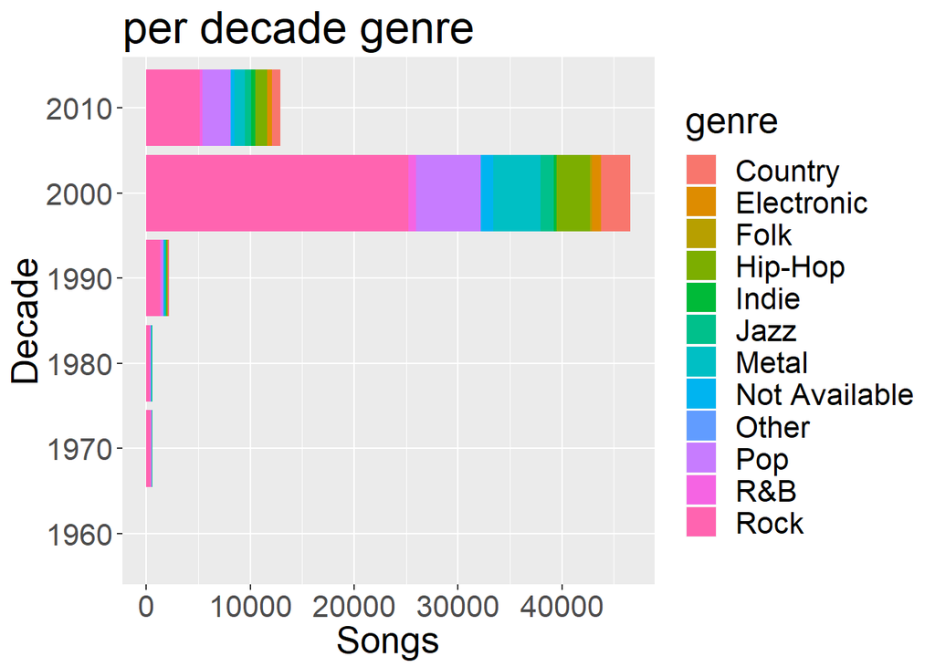

```
## # A tibble: 55 x 4
## # Groups:   genre [12]
##    genre         decade songs GenrePerc
##    <fct>         <fct>  <int>     <dbl>
##  1 Rock          2000   25245    0.402
##  2 Pop           2000    6274    0.0998
##  3 Rock          2010    5139    0.0818
##  4 Metal         2000    4568    0.0727
##  5 Hip-Hop       2000    3200    0.0509
##  6 Country       2000    2826    0.0450
##  7 Pop           2010    2704    0.0430
##  8 Rock          1990    1345    0.0214
##  9 Jazz          2000    1261    0.0201
## 10 Not Available 2000    1173    0.0187
## # ... with 45 more rows
```

With the above charts we see the large percentage of rock songs that are within the dataset. Furthermore, we see that while the 2000’s and 2010’s decades had a wider varity of genre’s, Rock was still very predominant in the percentage of songs that are that type from the dataset. This is somewhat surprising as new forms of music such as Hip Hop and Pop became so popular at this time.

## Word Plot

```r
#Could not run effectively on time.
```

## Words by Artist

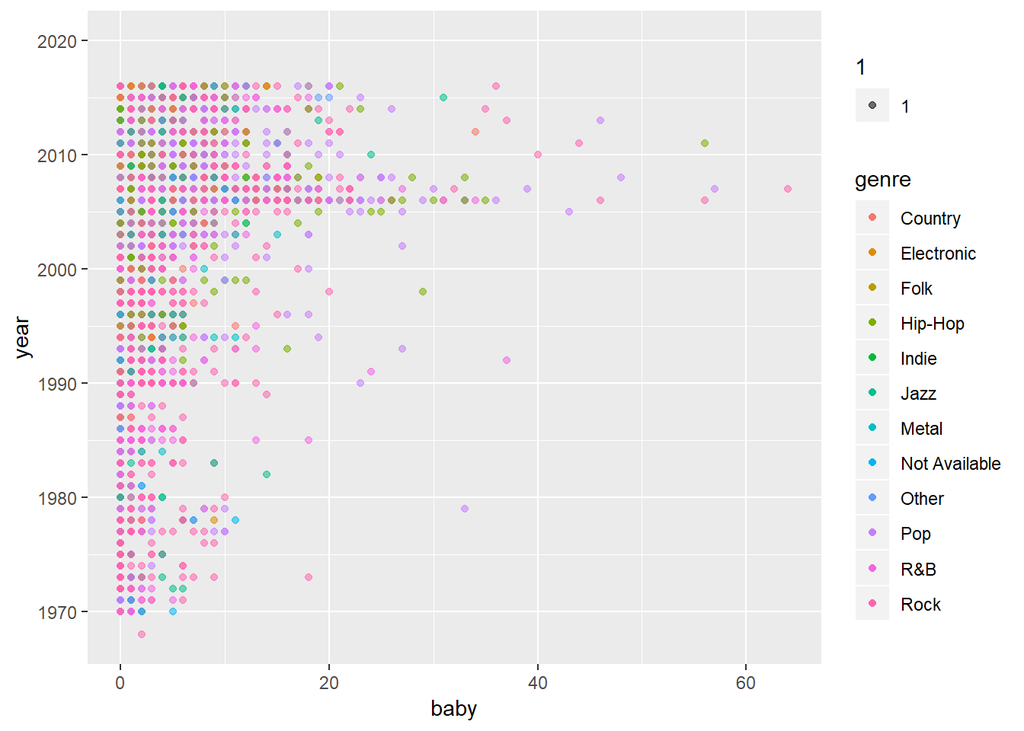

```r
# Making lyrics into factor to be able to use str_count

dt_lyrics2 <- dt_lyrics
dt_lyrics2$lyrics <- as.factor(dt_lyrics2$lyrics)

# Baby

dt_lyrics2$baby = str_count(dt_lyrics2$lyrics, 'baby')

ggplot(dt_lyrics2) + aes(baby, year, col = genre, alpha = 1) +
  geom_point() +
  ylim(1968,2020)
```

## Other important words

Next we will run the same process but with several other words that are commonly heard in music. Specifically, we will look at the prevalence of the words ‘Love’, ‘Rock’, and ‘Party’. These are not only words that are very often used in music, but they are also very indicative of what type of song it is.

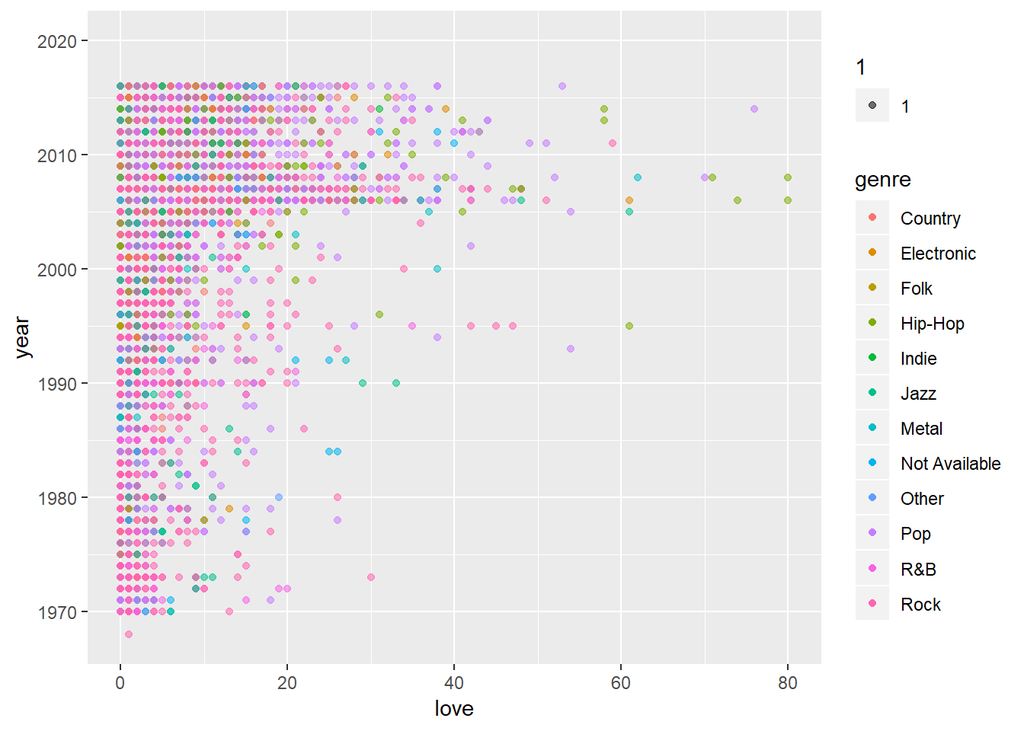

```r
# Love
dt_lyrics2$love = str_count(dt_lyrics2$lyrics, 'love')

ggplot(dt_lyrics2) + aes(love, year, col = genre, alpha = 1) +
  geom_point() +
  ylim(1968,2020)
```

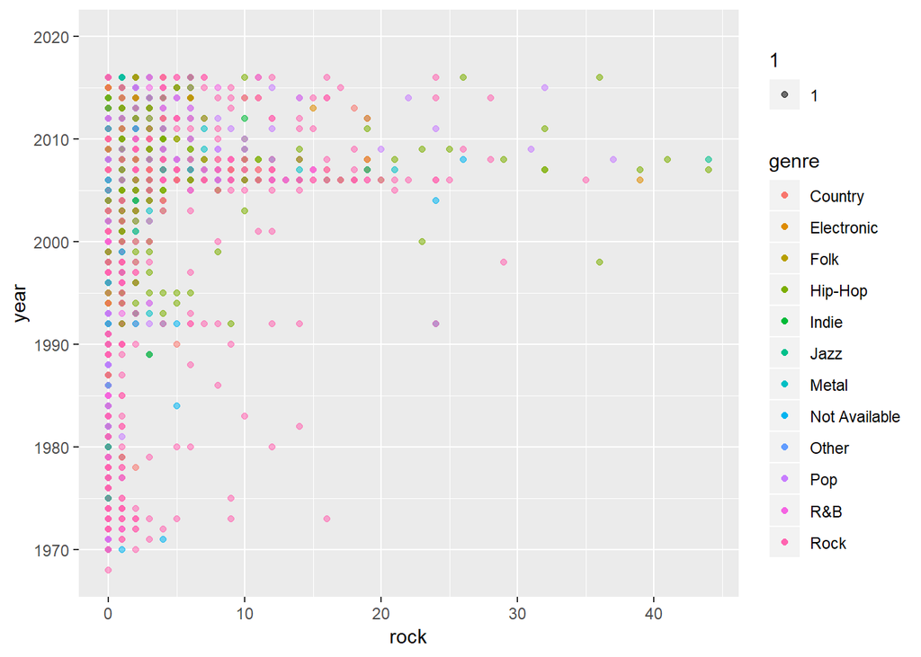

```r
# Rock
dt_lyrics2$rock = str_count(dt_lyrics2$lyrics, 'rock')

ggplot(dt_lyrics2) + aes(rock, year, col = genre, alpha = 1) +
  geom_point() +
  ylim(1968,2020)
```

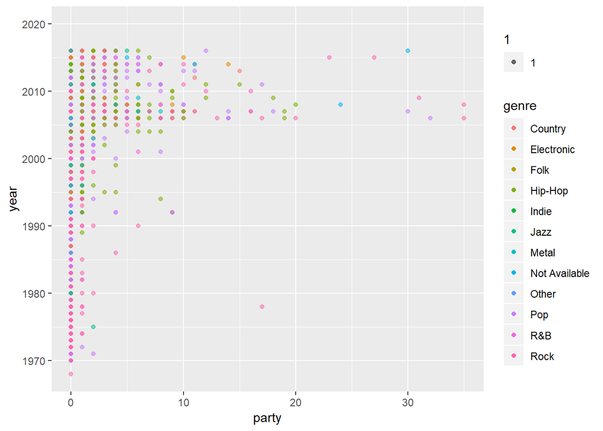

```r
# Party
dt_lyrics2$party = str_count(dt_lyrics2$lyrics, 'party')

ggplot(dt_lyrics2) + aes(party, year, col = genre, alpha = 1) +
  geom_point() +
  ylim(1968,2020)
```

```r
sum(dt_lyrics2$party)
```

```
## [1] 3405
```

```r
sum(dt_lyrics2$rock)
```

```
## [1] 8704
```

```r
sum(dt_lyrics2$love)
```

```
## [1] 91913
```

## Isolating without Rock

Due to the overwhelming number of rock songs within the dataset, we will isolate the table for just the non- rock songs to see the most commonly used words within them.

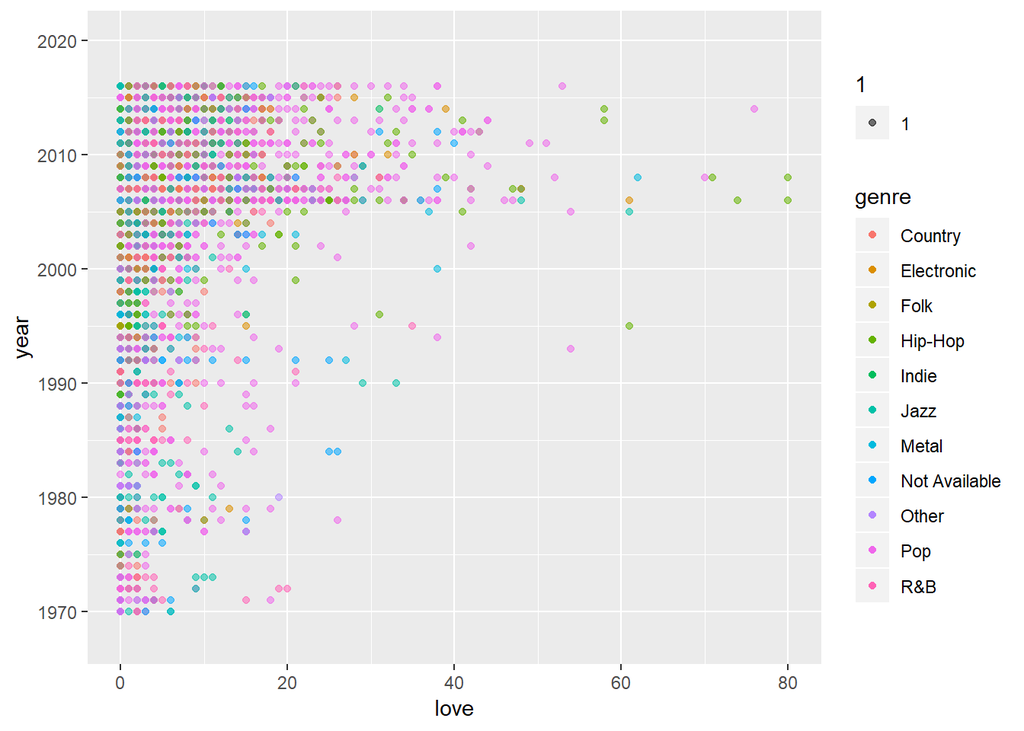

```r
lyricsNR <- dt_lyrics[dt_lyrics$genre != 'Rock',]

# Love
lyricsNR$love = str_count(lyricsNR$lyrics, 'love')

ggplot(lyricsNR) + aes(love, year, col = genre, alpha = 1) +
  geom_point() +
  ylim(1968,2020)
```

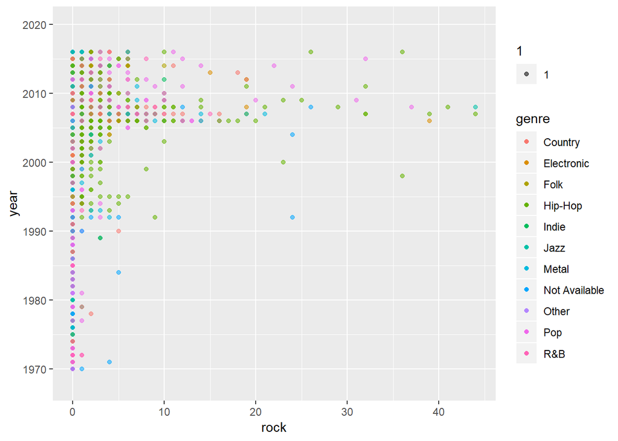

```r
# Rock
lyricsNR$rock = str_count(lyricsNR$lyrics, 'rock')

ggplot(lyricsNR) + aes(rock, year, col = genre, alpha = 1) +
  geom_point() +
  ylim(1968,2020)
```

## Summary

In this EDA we looked at the dataset of over 30000 songs to find patterns and insights about them. We saw that the data was heavily skewed for songs that were in the 2000 decade. Specifically, we found that songs in 2006 and 2007 comprised of nearly half of the whole dataset.

With a little more time (and experience) I would like to have been able to create a sentiment based word cloud based on the stemmed words that we created. The issue I came accross when creating a termdocumentmatrix is that the variables could not compute when trying to put the data into a matrix. This prevented me from being able to run the wordcloud (even with the truncated dataset with .5 of the initial observations). It would be good to learn best ways to achieve computational efficiency while also getting more comfort with running more complext text analysis models.